# Predicting stars: application of three machine learning algorithms

Marco Antonio Andrade Barrera  
November 14, 2015

### Introduction

The goal of this work is explore a sampling approach to predict users' rates using its free text review alone.

For this purpose, we used three machine learning algorithms: Support Vector Machines (SVM), Generalized Linear Model via Penalized Maximum Likelihood (GLMNET) and Maximum Entropy (MAXENTROPY).

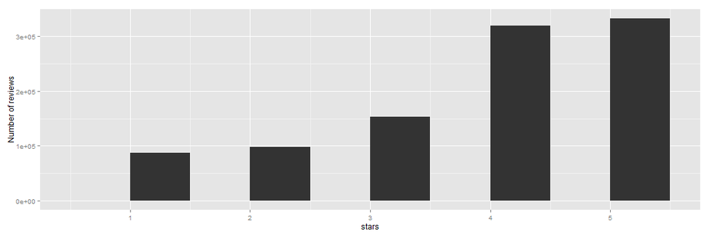

In the exploratory analysis, we calculated aproximate probabilities based on ocurrencies for each ranking. Defining \( X \) as the random variable that represents the number of rating stars for a new review, based of frequencies, the distribution of \( X \) is \( P(X=1)=0.088 \), \( P(X=2)=0.0985 \), \( P(X=3)=0.1551 \), \( P(X=4)=0.3226 \) and \( P(X=5)=0.3358 \).

### Results from 50,000 reviews random sample

Precision for each algorithm and category (ranking)

|  | 1 | 2 | 3 | 4 | 5 | General |
| --- | --- | --- | --- | --- | --- | --- |
| SVM | 0.62 | 0.45 | 0.48 | 0.52 | 0.64 | 0.542 |
| GLMNET | 0.64 | 0.47 | 0.48 | 0.43 | 0.57 | 0.518 |
| MAXENTROPY | 0.57 | 0.37 | 0.44 | 0.53 | 0.64 | 0.510 |

Recall for each algorithm and category (ranking)

|  | 1 | 2 | 3 | 4 | 5 | General |
| --- | --- | --- | --- | --- | --- | --- |
| SVM | 0.59 | 0.33 | 0.34 | 0.57 | 0.73 | 0.512 |
| GLMNET | 0.39 | 0.13 | 0.18 | 0.55 | 0.75 | 0.400 |
| MAXENTROPY | 0.59 | 0.38 | 0.40 | 0.49 | 0.70 | 0.512 |

### Conclusions

- The precision and recall measures presented are not very promising.
- In some cases, probability of guess the correct ranking is even lower that tossing a coin.
- Other tools should be used trying to improve the results. In this regard, others tools like sentimental analysis, ensemble agreement or simply considering additional variables could help.

Note: If you want to see the source files for report or this presentation, go to

[Report](https://mandradebs.github.io/dataScienceReportCP/report.Rmd) or [Presentation](https://mandradebs.github.io/dataScienceReportCP/slidedeck.Rpres)